# Projet de séries temporelles - Rapport final

## 6.3 Application des fonctions à une série doublement saisonnière

Tentons pour ce dernier point du projet de modéliser une série doublement saisonnière. Nous souhaitons modéliser la série `Sim2S`. La série est représentée graphiquement ci-dessous.

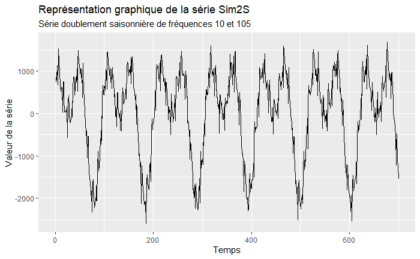

Supposons que nous n’ayons aucune idée quant à la façon de modéliser cette série. Nous la savons doublement saisonnière, nous la différencions saisonnièrement donc deux fois, et nous souhaitons appliquer la fonction `func_S3ARMA_part4`. C’est ce que nous faisons ci-dessous. Nous essayons 8 combinaisons, à savoir tous les modèles où seule la partie AR, qu’elle soit saisonnière ou non, peut être égale à 0 ou 1. Deux tableaux s’affichent ci-dessous : le premier correspond aux meilleurs modèles trouvés par la fonction selon l’AICc, et le second correspond à l’ensemble des résultats. Sans surprise, le meilleur modèle trouvé par la fonction est le modèle :

$$\textrm{SARMA(0,0)(1,0)[10](1,0)[105]}$$

```
#######################
### Fonction S3ARMA ###
#######################

Modèle SARMA à saisonnalités multiples
Version 2.0
Paul BOUST

Partie IV - Sélection automatique du meilleur modèle
----------------------------------------------------

Nombre de modèles : 8
Heure de début : 2020-12-16 10:30:13

Je réfléchis ... Vous avez le temps pour un petit café ! ☕

Modele 1 : S3ARMA(0,0)(0,0)[10](0,0)[105](0,0)[0]
Modele 2 : S3ARMA(1,0)(0,0)[10](0,0)[105](0,0)[0]
Modele 3 : S3ARMA(0,0)(1,0)[10](0,0)[105](0,0)[0]
Modele 4 : S3ARMA(1,0)(1,0)[10](0,0)[105](0,0)[0]
Modele 5 : S3ARMA(0,0)(0,0)[10](1,0)[105](0,0)[0]
Modele 6 : S3ARMA(1,0)(0,0)[10](1,0)[105](0,0)[0]
Modele 7 : S3ARMA(0,0)(1,0)[10](1,0)[105](0,0)[0]
Modele 8 : S3ARMA(1,0)(1,0)[10](1,0)[105](0,0)[0]

48.31389

### Fin d'éxécution
$Meilleurs_resultats
```

|  | Modele | AICc | Nb.coefs | Sig.score |
| --- | --- | --- | --- | --- |
| 7 | SARMA(0,0)(1,0)[10](1,0)[105](0,0)[0] | 7518.992 | 3 | 100.00000 |
| 3 | SARMA(0,0)(1,0)[10](0,0)[105](0,0)[0] | 7662.354 | 1 | 100.00000 |
| 4 | SARMA(1,0)(1,0)[10](0,0)[105](0,0)[0] | 7666.185 | 3 | 33.33333 |
| 5 | SARMA(0,0)(0,0)[10](1,0)[105](0,0)[0] | 7673.971 | 1 | 100.00000 |
| 2 | SARMA(1,0)(0,0)[10](0,0)[105](0,0)[0] | 7796.897 | 1 | 0.00000 |

| Modele | AICc | Nb.coefs | Sig.score |
| --- | --- | --- | --- |
| SARMA(0,0)(0,0)[10](0,0)[105](0,0)[0] | NA | NA | NA |
| SARMA(1,0)(0,0)[10](0,0)[105](0,0)[0] | 7796.897 | 1 | 0.00000 |
| SARMA(0,0)(1,0)[10](0,0)[105](0,0)[0] | 7662.354 | 1 | 100.00000 |
| SARMA(1,0)(1,0)[10](0,0)[105](0,0)[0] | 7666.185 | 3 | 33.33333 |
| SARMA(0,0)(0,0)[10](1,0)[105](0,0)[0] | 7673.971 | 1 | 100.00000 |
| SARMA(1,0)(0,0)[10](1,0)[105](0,0)[0] | NA | NA | NA |
| SARMA(0,0)(1,0)[10](1,0)[105](0,0)[0] | 7518.992 | 3 | 100.00000 |
| SARMA(1,0)(1,0)[10](1,0)[105](0,0)[0] | NA | NA | NA |

```
NA
```

```
#######################
### Fonction S3ARMA ###
#######################

Modèle SARMA à saisonnalités multiples
Version 2.0
Paul BOUST

Partie I - Estimation
---------------------

Heure de début : 2020-12-16 10:31:02

Je réfléchis ... Vous avez le temps pour un petit café ! ☕
Je crois avoir trouvé !

### Fin d'éxécution

#######################
### Fonction S3ARMA ###
#######################

Modèle SARMA à saisonnalités multiples
Version 2.0
Paul BOUST

Partie III - Dé-différenciations et Prévisions
----------------------------------------------

### Fin d'éxécution
```

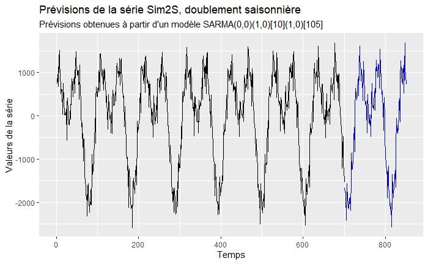

*Note : Nous n’explorons pas ici la triple saisonnalité, car nous n’avons pas au moment de la rédaction de ce devoir eu suffisamment de temps pour tester les différentes modélisations pour la série `Sim3S`. Le calcul des différents modèles possibles est extrêmement coûteux en temps. Cependant, nous sommes pleinement convaincus de l’efficacité de notre fonction pour une série triplement saisonnière.*

# 7 Bibliographie

Abadie, Jean, et François Meslier. 1979. « Étude de l’utilisation des modèles A.R.I.M.A. pour la prévision à très court terme de l’énergie journalière produite par électricité de France ». *RAIRO - Operational Research* 13 (1) : 37‑54. https://doi.org/https://doi.org/10.1051/ro/1979130100371.

Cancelo, José Ramón, Antoni Espasa, et Rosmarie Grafe. 2008. « Forecasting the electricity load from one day to one week ahead for the Spanish system operator ». *International Journal of Forecasting* 24 (4) : 588‑602. https://doi.org/https://doi.org/10.1016/j.ijforecast.2008.07.005.

Chui, F., A. Elkamel, R. Surit, E. Croiset, et P. L. Douglas. 2009. « Long-term electricity demand forecasting for power system planning using economic, demographic and climatic variables ». *European Journal of Industrial Engineering* 3 (3) : 277‑304. https://doi.org/10.1504/EJIE.2009.025049.

De Felice, Matteo, Andrea Alessandri, et Franco Catalano. 2015. « Seasonal climate forecasts for medium-term electricity demand forecasting ». *Applied Energy* 137 (1) : 435‑44. https://doi.org/https://doi.org/10.1016/j.apenergy.2014.10.030.

Hor, Ching-Lai, S. J. Watson, et S. Majithia. 2005. « Analyzing the impact of weather variables on monthly electricity demand ». *IEEE Transactions on Power Systems* 20 (4) : 2078‑85. https://doi.org/10.1109/TPWRS.2005.857397.

Hyndman, Rob J., et George Athanasopoulos. 2014. *Forecasting: Principles and Practice*. Heathmont, Vic : OTexts.

Ihara, Tomohiko, Yutaka Genchi, Takamune Sato, Kazuki Yamaguchi, et Yasuyuki Endo. 2008. « City-block-scale sensitivity of electricity consumption to air temperature and air humidity in business districts of Tokyo, Japan ». *Energy* 33 (11) : 1634‑45. https://doi.org/https://doi.org/10.1016/j.energy.2008.06.005.

Meira de Oliveira, Erick, et Fernando Luiz Cyrino Oliveira. 2018. « Forecasting mid-long term electric energy consumption through bagging ARIMA and exponential smoothing methods ». *Energy* 144 (1) : 776‑88. https://doi.org/https://doi.org/10.1016/j.energy.2017.12.049.

Mirasgedis, Sebastian, Yiannis Sarafidis, Elena Georgopoulou, Dimitri Lalas, M. Moschovits, Fotios Karagiannis, et D. Papakonstantinou. 2006. « Models for mid-term electricity demand forecasting incorporating weather influences ». *Energy* 31 (2-3) : 208‑27. https://doi.org/https://doi.org/10.1016/j.energy.2005.02.016.

Soares, Lacir J., et Marcelo C. Medeiros. 2008. « Modeling and forecasting short-term electricity load: A comparison of methods with an application to Brazilian data ». *International Journal of Forecasting* 24 (4) : 630‑44. https://doi.org/https://doi.org/10.1016/j.ijforecast.2008.08.003.

Taylor, James, W. 2010. « Triple Seasonal Methods for Short-Term Electricity Demand Forecasting ». *European Journal of Operational Research* 204 (1) : 139‑52. https://doi.org/https://doi.org/10.1016/j.ejor.2009.10.003.